# Unevaluated expressions

A better approach is to **blank the cell with a ribbon**. We have to eliminate strip titles from the theme for this approach to work.

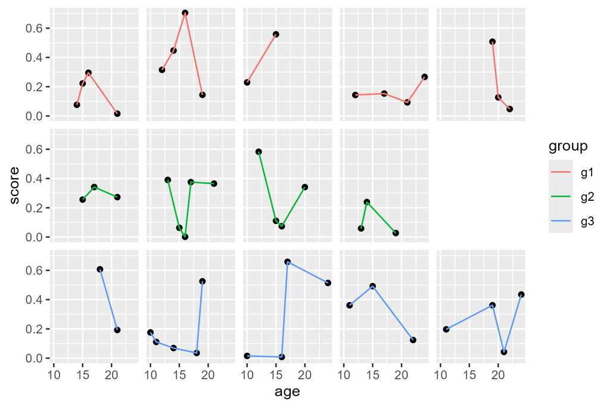

```r
ggplot(data, aes(x = age, y = score)) +
  geom_point(na.rm = TRUE) +
  geom_line(aes(color = group), na.rm = TRUE) +
  geom_ribbon(
    aes(ymin = -Inf, ymax = Inf),
    data = tibble(
      id = "i2",
      age = c(-Inf, Inf),
      group = "g2",
      score = NA_real_
    ),
    fill = "white",
    color = "white"
  ) +
  facet_wrap("id", ncol = 5) +
  theme(strip.text.x = element_blank())
```

[Brenton on Twitter](https://twitter.com/bmwiernik/status/1484263988137504771?s=20) suggested numbering IDs *within* groups and using `facet_grid()`. That works, and it also can give labeled rows.

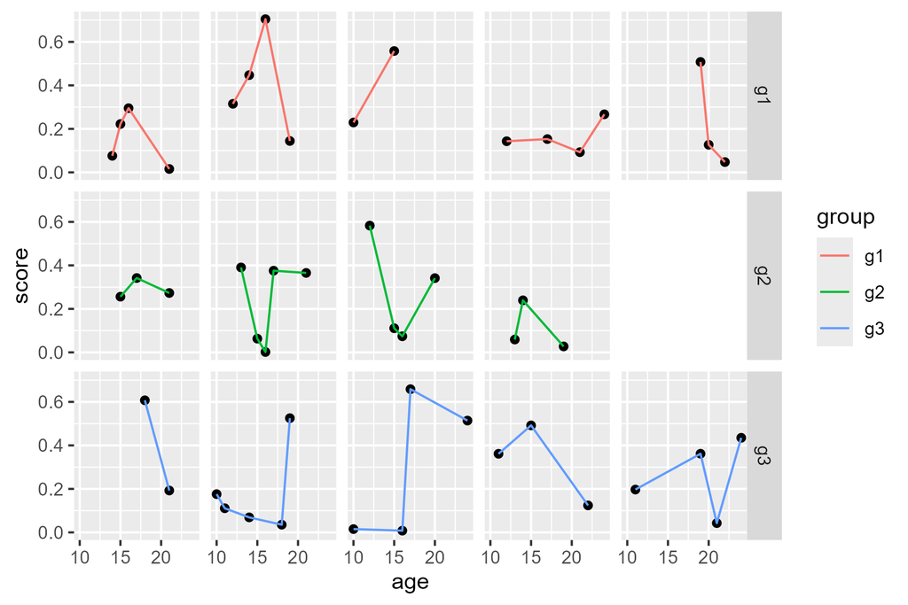

```r
data <- data %>%
  group_by(group) %>%
  mutate(col_num = match(id, unique(id))) %>%
  ungroup()

ggplot(data, aes(x = age, y = score)) +
  geom_point(na.rm = TRUE) +
  geom_line(aes(color = group), na.rm = TRUE) +
  geom_ribbon(
    aes(ymin = -Inf, ymax = Inf),
    data = tibble(
      col_num = 5,
      age = c(-Inf, Inf),
      group = "g2",
      score = NA_real_
    ),
    fill = "white",
    color = "white"
  ) +
  facet_grid(group ~ col_num) +
  theme(strip.text.x = element_blank())
```

### Compute spline predictions manually from GAMLSS

My goal is write down some reusable code for how to get spline predictions for unobserved *x* values by hand from a GAMLSS model.

#### Problem setup

Here are 98 random points from a subrange of the intelligibility dataset.

```r
library(tidyverse)
suppressMessages(library(gamlss))
select <- dplyr::select

data_intel <- tibble::tribble(
   ~id, ~age_months, ~mean_intelligibility,
    1L,          44,                  0.74,
    2L,          49,                 0.779,
    3L,          56,                 0.686,
    4L,          51,                 0.675,
    5L,          42,                 0.785,
    6L,          42,                 0.708,
    7L,          38,                 0.557,
    8L,          44,                 0.756,
    9L,          56,                  0.64,
   10L,          50,                 0.767,
   11L,          48,                 0.858,
   12L,          53,                  0.94,
   13L,          49,                 0.673,
   14L,          56,                 0.928,
   15L,          54,                 0.827,
   16L,          51,                 0.868,
   17L,          53,                 0.784,
   18L,          50,                 0.908,
   19L,          37,                 0.458,
   20L,          37,                 0.184,
   21L,          51,                 0.688,
   22L,          53,                 0.753,
   23L,          43,                 0.802,
   24L,          47,                 0.841,
   25L,          45,                 0.523,
   26L,          37,                 0.288,
   27L,          42,                 0.672,
   28L,          50,                 0.777,
   29L,          54,                 0.749,
   30L,          53,                 0.901,
   31L,          55,                 0.806,
   32L,          45,                 0.646,
   33L,          45,                 0.689,
   34L,          45,                 0.806,
   35L,          46,                 0.859,
   36L,          36,                 0.557,
   37L,          38,                 0.606,
   38L,          50,                 0.804,
   39L,          44,                 0.853,
   40L,          51,                 0.747,
   41L,          37,                 0.659,
   42L,          48,                 0.883,
   43L,          45,                 0.798,
   44L,          39,                 0.483,
   45L,          59,                 0.976,
   46L,          58,                 0.786,
   48L,          48,                 0.775,
   49L,          47,                 0.896,
   50L,          38,                 0.921,
   51L,          41,                 0.686,
   53L,          54,                  0.72,
   54L,          51,                 0.965,
   55L,          44,                 0.777,
   56L,          42,                  0.53,
   57L,          36,                 0.707,
   58L,          60,                 0.908,
   59L,          37,                 0.566,
   60L,          51,                 0.598,
   61L,          58,                 0.938,
   62L,          54,                 0.925,
   63L,          47,                 0.757,
   64L,          42,                  0.63,
   65L,          45,                 0.764,
   66L,          59,                  0.85,
   67L,          47,                 0.786,
   68L,          38,                 0.781,
   69L,          44,                 0.929,
   70L,          36,                 0.356,
   71L,          55,                 0.802,
   72L,          54,                 0.864,
   73L,          43,                 0.864,
   74L,          49,                 0.848,
   75L,          38,                 0.574,
   76L,          53,                 0.916,
   77L,          41,                  0.85,
   78L,          59,                 0.851,
   79L,          46,                 0.444,
   80L,          55,                 0.778,
   81L,          54,                 0.931,
   82L,          50,                  0.32,
   83L,          58,                 0.855,
   84L,          39,                  0.64,
   85L,          50,                 0.727,
   86L,          50,                 0.857,
   87L,          39,                 0.731,
   88L,          46,                 0.624,
   89L,          53,                 0.951,
   90L,          46,                 0.873,
   91L,          47,                 0.897,
   92L,          46,                 0.748,
   93L,          59,                 0.936,
   94L,          50,                 0.881,
   95L,          43,                 0.815,
   96L,          44,                 0.768,
   97L,          43,                 0.789,
   98L,          50,                 0.728,
   99L,          38,                 0.794,
  100L,          44,                 0.509
)
data_intel <- data_intel %>%
  arrange(age_months)
```

But note that we are missing data from three ages (*x* values).

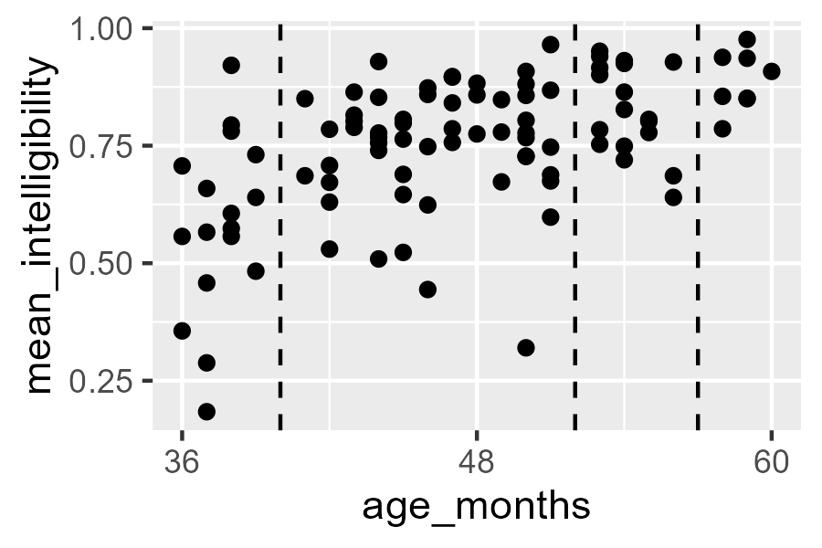

Intelligibility data but there are no observations at 40, 52, and 57 months

```r
ggplot(data_intel) +
  aes(x = age_months, y = mean_intelligibility) +
  geom_point() +
  geom_vline(xintercept = c(40, 52, 57), linetype = "dashed") +
  scale_x_continuous(breaks = c(36, 48, 60))
```

Here is how we would fit a beta-regression model as we did in the growth curve paper.

```r
fit_beta_gamlss <- function(data, mu_df = 3, sigma_df = 2) {
  BE <- gamlss.dist::BE
  gamlss.control <- gamlss::gamlss.control
  ns <- splines::ns

  model <- wisclabmisc::mem_gamlss(
    mean_intelligibility ~ ns(age_months, df = mu_df),
    sigma.formula = ~ ns(age_months, df = sigma_df),
    family = BE(),
    data = data,
    control = gamlss.control(trace = FALSE)
  )

  model$.user$mu_df <- mu_df
  model$.user$sigma_df <- sigma_df

  model$.user$mu_basis <- ns(data$age_months, mu_df)
  model$.user$sigma_basis <- ns(data$age_months, sigma_df)

  model
}

model <- fit_beta_gamlss(data_intel, mu_df = 3, sigma_df = 2)
```

Then we can get centiles pretty easily for the existing *x* values. But note the three gaps on the percentile line.

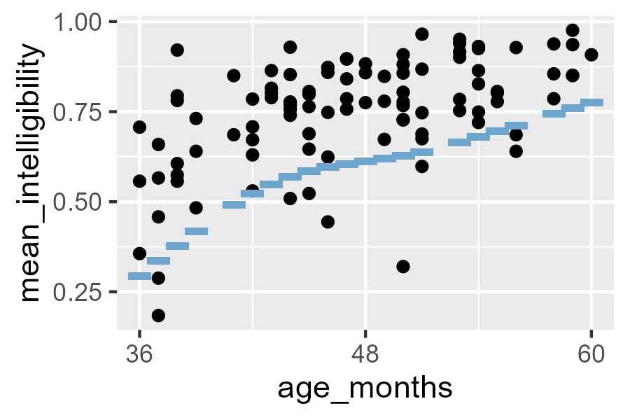

Intelligibility data with points from the 10th percentile line

```r
centiles <- data_intel %>%
  select(age_months) %>%
  wisclabmisc::predict_centiles(model)

ggplot(data_intel) +
  aes(x = age_months, y = mean_intelligibility) +
  geom_point() +
  geom_point(
    aes(y = c10),
    data = centiles,
    color = "skyblue3",
    size = 10,
    shape = "-"
  ) +
  scale_x_continuous(breaks = c(36, 48, 60))
```

If we ask GAMLSS to give us centiles for those gaps—**herein lies the problem**—we might get a warning message like the following:

```r
centiles2 <- data_intel %>%
  select(age_months) %>%
  tidyr::expand(age_months = tidyr::full_seq(age_months, 1)) %>%
  wisclabmisc::predict_centiles(model)
```

```
#> Warning in predict.gamlss(obj, what = "mu", newdata = newx, type = "response", : There is a discrepancy  between the original and the re-fit
#>  used to achieve 'safe' predictions
#>
```

I don’t want to mess around in unsafe territory with GAMLSS. (What if they change how they handle this problem in the future?) So I would like to estimate values for those missing *x* values from the spline by hand.

#### Problem solution

Use `predict()` on the spline object to get the values of the basis functions at the new x values. I stashed the original spline object inside of the model.

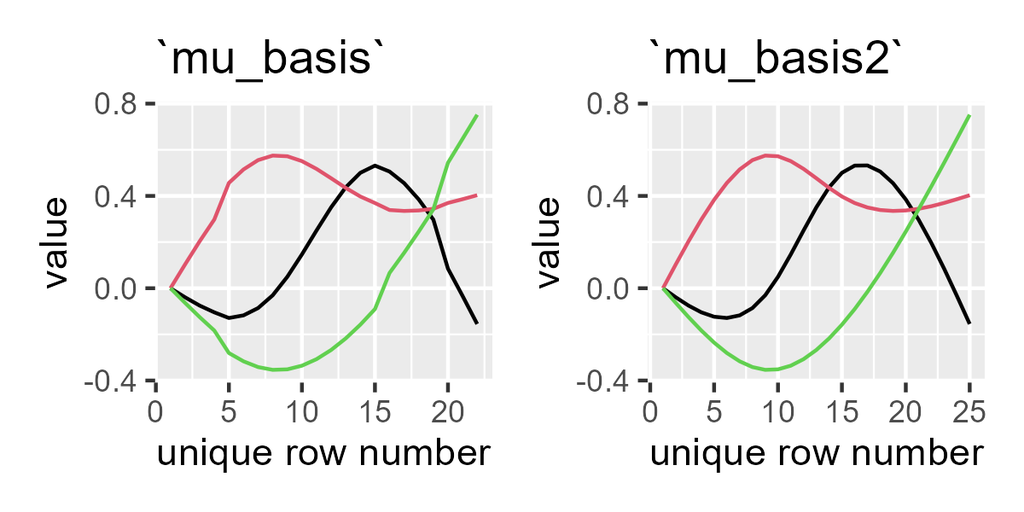

Basis functions for observed data (left) and the age range (right). The full age range is a little bit smoother than the observed data.

```r
mu_basis <- model$.user$mu_basis
ages_to_predict <- data_intel %>%
  tidyr::expand(age_months = tidyr::full_seq(age_months, 1))

mu_basis2 <- predict(mu_basis, newx = ages_to_predict$age_months)

library(patchwork)
tjmisc::ggmatplot(mu_basis) +
  tjmisc::ggmatplot(mu_basis2)
```

We do the following to get model parameters at each age. **This code is the point of this note.**

```r
mu_basis <- model$.user$mu_basis
sigma_basis <- model$.user$sigma_basis
newx <- ages_to_predict$age_months

mu_basis2 <- cbind(1, predict(mu_basis, newx = newx))
sigma_basis2 <- cbind(1, predict(sigma_basis, newx = newx))

manual_centile <- tibble::tibble(
  age_months = newx,
  # multiply coefficients and undo link function
  mu = plogis(mu_basis2 %*% coef(model, what = "mu"))[, 1],
  sigma = plogis(sigma_basis2 %*% coef(model, what = "sigma"))[, 1],
  # now take centiles
  c10 = gamlss.dist::qBE(.1, mu, sigma)
)
manual_centile
```

```
#> # A tibble: 25 × 4
#>    age_months    mu sigma   c10
#>         <dbl> <dbl> <dbl> <dbl>
#>  1         36 0.522 0.341 0.294
#>  2         37 0.560 0.334 0.336
#>  3         38 0.596 0.328 0.378
#>  4         39 0.630 0.321 0.418
#>  5         40 0.661 0.315 0.456
#>  6         41 0.688 0.309 0.491
#>  7         42 0.712 0.304 0.522
#>  8         43 0.731 0.298 0.548
#>  9         44 0.745 0.293 0.569
#> 10         45 0.755 0.288 0.584
#> # ℹ 15 more rows
```

Let’s look at our manually computed 10th percentile versus the package-provided one.

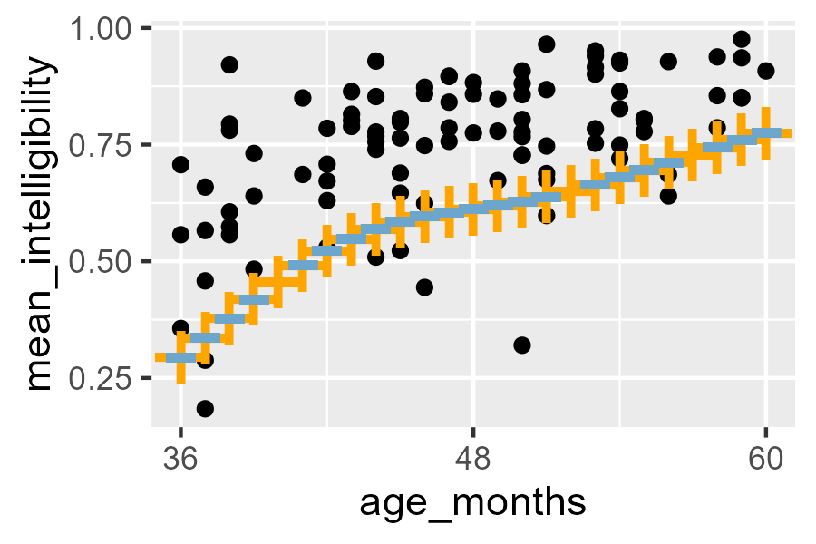

Intelligibility data with points from the 10th percentile line provided by `centiles.pred()` (blue hyphens) and computed by hand (orange pluses).

```r
ggplot(data_intel) +
  aes(x = age_months, y = mean_intelligibility) +
  geom_point() +
  geom_point(
    aes(y = c10),
    data = manual_centile,
    color = "orange",
    size = 10,
    shape = "+"
  ) +
  geom_point(
    aes(y = c10),
    data = centiles,
    color = "skyblue3",
    size = 10,
    shape = "-"
  ) +
  scale_x_continuous(breaks = c(36, 48, 60))
```

### Count number of function calls in some R code

Do data analysis on `getParseData()` result.

```r
code <- quote({
  check_out <- my(fancy(code))
  here_is <- some(fancy(code))
})

parse_data <- getParseData(parse(text = deparse(code), keep.source = TRUE))
head(parse_data)
```

```
#>    line1 col1 line2 col2 id parent       token terminal      text
#> 55     1    1     4    1 55      0        expr    FALSE
#> 1      1    1     1    1  1     55         '{'     TRUE         {
#> 25     2    5     2   32 25     55        expr    FALSE
#> 3      2    5     2   13  3      5      SYMBOL     TRUE check_out
#> 5      2    5     2   13  5     25        expr    FALSE
#> 4      2   15     2   16  4     25 LEFT_ASSIGN     TRUE        <-
```

Count tokens using results of `all.names()` and `all.vars()`.

```r
names <- all.names(code)
vars <- all.vars(code)

# Just the non-variable tokens
names[!names %in% vars]
```

```
#> [1] "{"     "<-"    "my"    "fancy" "<-"    "some"  "fancy"
```

## December 2021

Source: `2021-12-07.Rmd`

### Quick hits

rlang provides [`done()`](https://rlang.r-lib.org/reference/done.html) to break out of a loop.

This paper uses by-word entropy as a measure of intelligibility. https://doi.org/10.1017/S0305000921000714

**Leslie matrix**. Advent of Code day 6 (simulating population growth) can be done with matrix multiplication on a [Leslie matrix](https://en.wikipedia.org/wiki/Leslie_matrix) which is a transition matrix on age counts:

> The Leslie matrix is a square matrix with the same number of rows and columns as the population vector has elements. The (i,j)th cell in the matrix indicates how many individuals will be in the age class i at the next time step for each individual in stage j.

**Monads in one sentence**.

> A monad is the minimum amount of structure needed to overload function composition in a way that “performs an extra computation” on the intermediate value. – https://www.youtube.com/watch?v=Nq-q2USYetQ&feature=youtu.be

## November 2021

Source: `2021-11-22.Rmd`

### Quick hits

**Base graphics in knitr**. I learned while porting over some old notes that `par()` options are not preserved between knitr chunks unless `opts_knit$get("global.par")` is `TRUE`. It’s `FALSE` by default. No funny business using `old <- par(...)`

**Sampling a swimming pool depth**. Jorbs on his Slay the Spire stream commented problems with big data. He used [a nice analogy](https://www.youtube.com/watch?v=kHS-tFnJKqA&t=5712s) for sampling bias. Imagine you have a swimming pool and we can’t see the bottom of it. We want to measure the average depth of it. No amount of big data will accurately estimate the depth with all the samples come from the shallow end of the pool. But if you smartly sample the pool with a grid of points, then you can come up with an accurate estimate from relatively few points. This example is nice because it can illustrate accuracy versus precision.

The analogy also funnily resembles an analogy used for Hamilitonian Monte Carlo: a puck skating around a smooth curved surface. If the pool is the posterior distribution and the depth is the negative log posterior density, then we want to explore that pool too.

Paul recommended using Frank Harrell’s `rms::orm()` function for ordinal regression.

### `eval()` is stack inconsistent (whatever that means)

`base::eval()` and `rlang::eval_bare()` [do things differently](https://rlang.r-lib.org/reference/eval_bare.html).

Here are the examples from `?eval_bare()`

```r
# eval_bare() works just like base::eval() but you have to create
# the evaluation environment yourself:
eval_bare(quote(foo), env(foo = "bar"))
```

```
#> [1] "bar"
```

```r
# eval() has different evaluation semantics than eval_bare(). It
# can return from the supplied environment even if its an
# environment that is not on the call stack (i.e. because you've
# created it yourself). The following would trigger an error with
# eval_bare():
ret <- quote(return("foo"))
eval(ret, env())
```

```
#> [1] "foo"
```

```r
# eval_bare(ret, env())  # "no function to return from" error

# Another feature of eval() is that you can control surround loops:
bail <- quote(break)
while (TRUE) {
  eval(bail)
  # eval_bare(bail)  # "no loop for break/next" error
}

# To explore the consequences of stack inconsistent semantics, let's
# create a function that evaluates `parent.frame()` deep in the call
# stack, in an environment corresponding to a frame in the middle of
# the stack. For consistency with R's lazy evaluation semantics, we'd
# expect to get the caller of that frame as result:
fn <- function(eval_fn) {
  list(
    returned_env = middle(eval_fn),
    actual_env = current_env()
  )
}
middle <- function(eval_fn) {
  deep(eval_fn, current_env())
}
deep <- function(eval_fn, eval_env) {
  expr <- quote(parent.frame())
  eval_fn(expr, eval_env)
}

# With eval_bare(), we do get the expected environment:
fn(rlang::eval_bare)
```

```
#> $returned_env
#> <environment: 0x55cac3595df8>
#>
#> $actual_env
#> <environment: 0x55cac3595df8>
#>
```

```r
# But that's not the case with base::eval():
fn(base::eval)
```

```
#> $returned_env
#> <environment: 0x55cac1cc7980>
#>
#> $actual_env
#> <environment: 0x55cac1cc2170>
#>
```

### The Gaussian KDE is a sum of baby Gaussians?!

Today I learned [from here](https://support.numxl.com/hc/en-us/articles/216478703-Kernel-density-estimation-KDE-Plot) that the Gaussian KDE is the sum of a bunch of little Gaussian curves. Here look:

```r
library(tidyverse)
```

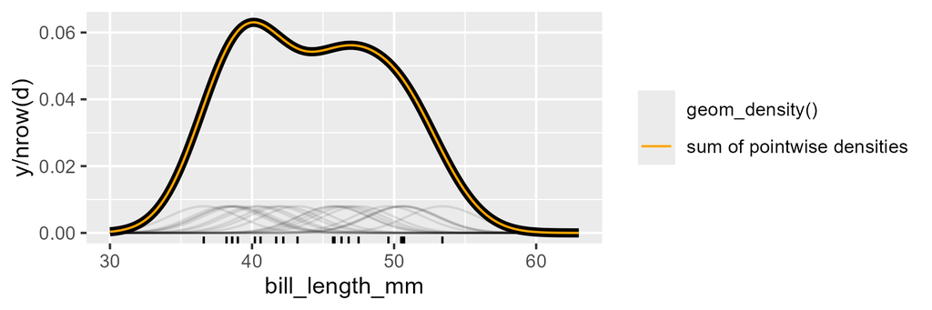

```r
library(palmerpenguins)

d <- penguins %>%
  filter(!is.na(bill_length_mm)) %>%
  sample_n(size = 20)

# grid of xs
x <- seq(30, 63, length.out = 200)

# compute density of xs using each observed value
# as the mean.
l <- lapply(
  d$bill_length_mm,
  function(m) {
    data.frame(
      x = x,
      y = dnorm(x, mean = m, sd = bw.nrd0(d$bill_length_mm))
    )
  }
)
dl <- bind_rows(l, .id = "obs")

# plot them, their sum, and the default density curve
ggplot(d) +
  aes(x = bill_length_mm) +
  geom_density(aes(color = "geom_density()"), size = 2, show.legend = FALSE) +
  geom_rug() +
  geom_line(
    aes(x = x, y = y / nrow(d), group = obs),
    data = dl, alpha = .1
  ) +
  stat_summary(
    aes(x = x, y = y / nrow(d), color = "sum of pointwise densities"),
    data = dl,
    # alpha = .1,
    geom = "line",
    fun = "sum",
    # color = "orange"
  ) +
  scale_color_manual(values = c("black", "orange")) +
  labs(color = NULL)
```

### Using closures to make 16 related functions

The [R Open Sci newsletter](https://ropensci.org/blog/2021/11/30/ropensci-news-digest-november-2021/#function-specific-and-package-specific-environments) linked to [a mailing list thread](https://www.mail-archive.com/r-package-devel@r-project.org/msg07413.html) about how to stash data inside of an R package.

Duncan Murdoch suggests using a function factory to create closures that can access data in the parent environment.

> Your `local()` call can create several functions and return them in a list; then just those functions have access to the local variables. For example,

> ```r
> createFns <- function() {
>
>    .fooInfo <- NULL
>
>    fn1 <- function (...) { ... }
>    fn2 <- function (...) { ... }
>
>    list(fn1 = fn1, fn2 = fn2)
> }
>
> fns <- createFns()
> fn1 <- fns$fn1
> fn2 <- fns$fn2
> ```

> Now `fn1` and `fn2` are functions that can see `.fooInfo`, and nobody else can (without going through contortions).

(I had to fix the code to create a real function factory.)

Then Martin Mächler replies to say yup, this is what we do in base R.

> Note that the above approach has been how `nls()` has been implemented for R … a very long time ago {before R 1.0.0}

> e.g. from `example(nls)`:

> ```r
> DNase1 <- subset(DNase, Run == 1)
> fm1 <- nls(density ~ SSlogis(log(conc), Asym, xmid, scal), DNase1)
> str(fm1$m)
> ```

> ```
> #> List of 16
> #>  $ resid     :function ()
> #>  $ fitted    :function ()
> #>  $ formula   :function ()
> #>  $ deviance  :function ()
> #>  $ lhs       :function ()
> #>  $ gradient  :function ()
> #>  $ conv      :function ()
> #>  $ incr      :function ()
> #>  $ setVarying:function (vary = rep_len(TRUE, np))
> #>  $ setPars   :function (newPars)
> #>  $ getPars   :function ()
> #>  $ getAllPars:function ()
> #>  $ getEnv    :function ()
> #>  $ trace     :function ()
> #>  $ Rmat      :function ()
> #>  $ predict   :function (newdata = list(), qr = FALSE)
> #>  - attr(*, "class")= chr "nlsModel"
> ```

> ```r
> # so 16 functions, all sharing the *same* environment very
> # efficiently and nicely
>
> # this is *the* environment for the fitted model:
> fmE <- environment(fm1$m[[1]])
> ls.str(fmE)
> ```

> ```
> #> convCrit : function ()
> #> dev :  num 0.00479
> #> env : <environment: 0x000002cf8043d5f0>
> #> form : Class 'formula'  language density ~ SSlogis(log(conc), Asym, xmid, scal)
> #> getPars : function ()
> #> getPars.noVarying : function ()
> #> getPars.varying : function ()
> #> getRHS : function ()
> #> getRHS.noVarying : function ()
> #> getRHS.varying : function ()
> #> gradCall :  language attr(ans, "gradient")[c(TRUE, TRUE, TRUE, TRUE, TRUE, TRUE, TRUE, TRUE,  TRUE, TRUE, TRUE, TRUE, TRUE, TRUE, TRUE| __truncated__ ...
> #> ind : List of 3
> #>  $ Asym: int 1
> #>  $ xmid: int 2
> #>  $ scal: int 3
> #> internalPars :  Named num [1:3] 2.35 1.48 1.04
> #> lhs :  num [1:16] 0.017 0.018 0.121 0.124 0.206 0.215 0.377 0.374 0.614 0.609 ...
> #> nDcentral :  logi FALSE
> #> npar :  int 3
> #> QR : List of 4
> #>  $ qr   : num [1:16, 1:3] -1.5221 0.0086 0.0314 0.0314 0.0584 ...
> #>  $ rank : int 3
> #>  $ qraux: num [1:3] 1.01 1.03 1.28
> #>  $ pivot: int [1:3] 1 2 3
> #> resid :  num [1:16] -0.01368 -0.01268 0.00895 0.01195 -0.00258 ...
> #> rhs :  num [1:16] 0.0307 0.0307 0.1121 0.1121 0.2086 ...
> #> scaleOffset :  num 0
> #> setPars : function (newPars)
> #> setPars.noVarying : function (newPars)
> #> setPars.varying : function (newPars)
> #> upper :  NULL
> #> useParams :  logi [1:3] TRUE TRUE TRUE
> #> wts :  num [1:16] 1 1 1 1 1 1 1 1 1 1 ...
> ```

> so the environment “contains” the functions themselves (but quite a few more things) and for an environment that means it only has pointers to the same function objects which are *also* in `fm1$m`.

> **So, there has been a nice convincing and important example on how to do this - inside R for more than two decennia.**

Final emphasis was added by me.

## OneNote archive

Source: `2021-11-01-archival-notes.Rmd`

Here is a bunch of pre-2021 items from OneNote and elsewhere.

#### Added variable plots (2019-05-14)

- Let `m = y ~ x1 + ...` be the full regression model
- Let `m_y1 = y ~ ...` (all of the predictors except x1)
- Let `m_x1 = x1 ~ ...` (regress x1 on those same predictors)
- Let `m_partial = resid(m_y1) ~ resid(m_x1)`
- The plot of `resid(m_x1)` versus `resid(m_y1)` is the added variable plot. It shows “X1 | others)” and “y | others”
- Residuals in the final `m_partial` model will be same as residuals from full model `m`
- Coefficient of `x1` in final `m_partial` model will be same as coefficient from full model `m`.

AV plots by hand and by `car::avPlot()`

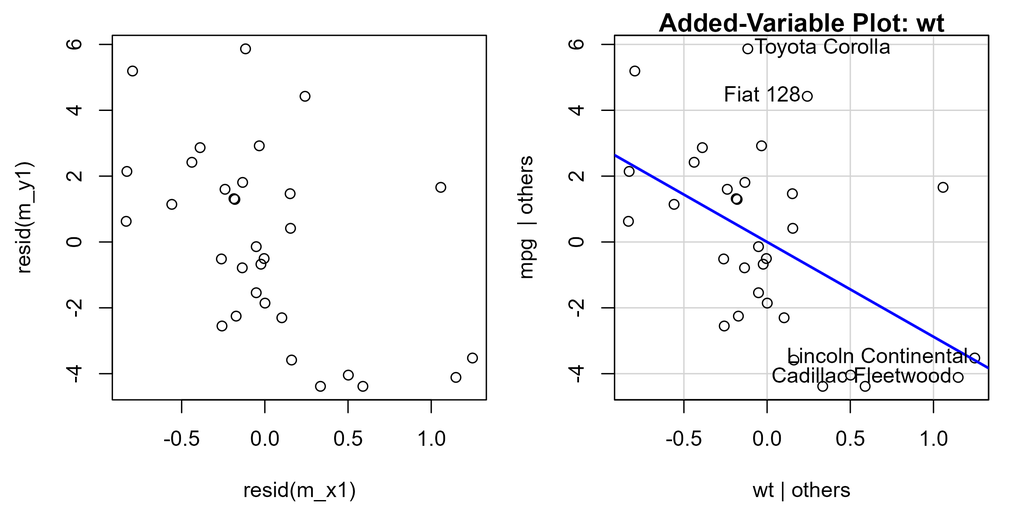

```r
par(mar = c(4, 4, 1, 1))

m <- lm(mpg ~ wt + hp + am, mtcars)
m_y1 <- lm(mpg ~ hp + am, mtcars)
m_x1 <- lm(wt ~ hp + am, mtcars)
m_partial <- lm(resid(m_y1) ~ resid(m_x1))

library(patchwork)
p1 <- wrap_elements(
  full = ~ plot(resid(m_x1), resid(m_y1))
)
p2 <- wrap_elements(
  full = ~ car::avPlot(m, "wt")
)

p1 + p2
```

```r
all.equal(residuals(m_partial), residuals(m))
```

```
#> [1] TRUE
```

```r
coef(m)["wt"]
```

```
#>        wt
#> -2.878575
```

```r
coef(m_partial)[2]
```

```
#> resid(m_x1)
#>   -2.878575
```

What about interactions?

#### R 3.6.0 released! (2019-04-26)

Highlights for me

- New `sample()` implementation
- New function `asplit()` allow splitting an array or matrix by its margins.
- Functions mentioned I didn’t know about: `lengths()`, `trimws()`, `extendrange()`, `convertColor()`, `strwidth()`

### Standardized gamma distributions (2019-04-18)

A gamma times a positive non-zero constant is still a gamma. Paul and I used this fact to standardize results from different models onto a single “z” scale. Here’s a made-up example.

Simulate some gamma-distributed data.

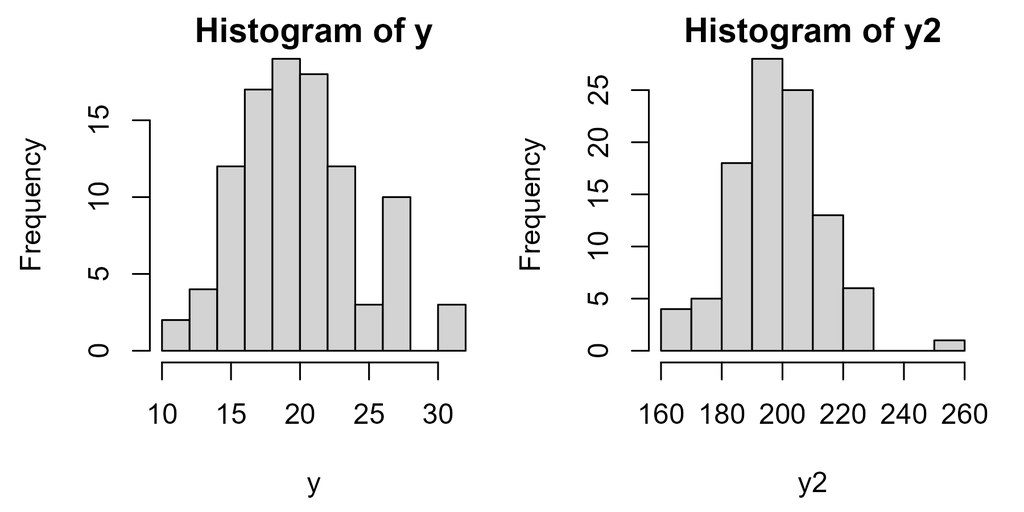

```r
library(patchwork)
set.seed(20211122)
par(mar = c(4, 4, 1, 1))

y <- rgamma(n = 100, shape = 20)
y2 <- rgamma(n = 100, shape = 200)
wrap_elements(full = ~ hist(y)) +
  wrap_elements(full = ~ hist(y2))
```

Fit a GLM

```r
get_shape <- function(model) {
  1 / summary(model)[["dispersion"]]
}

m <- glm(y ~ 1, Gamma(link = "identity"))
m2 <- glm(y2 ~ 1, Gamma(link = "identity"))

get_shape(m)
```

```
#> [1] 21.09197
```

```r
get_shape(m2)
```

```
#> [1] 178.6259
```

The two `z` values have similar scales.

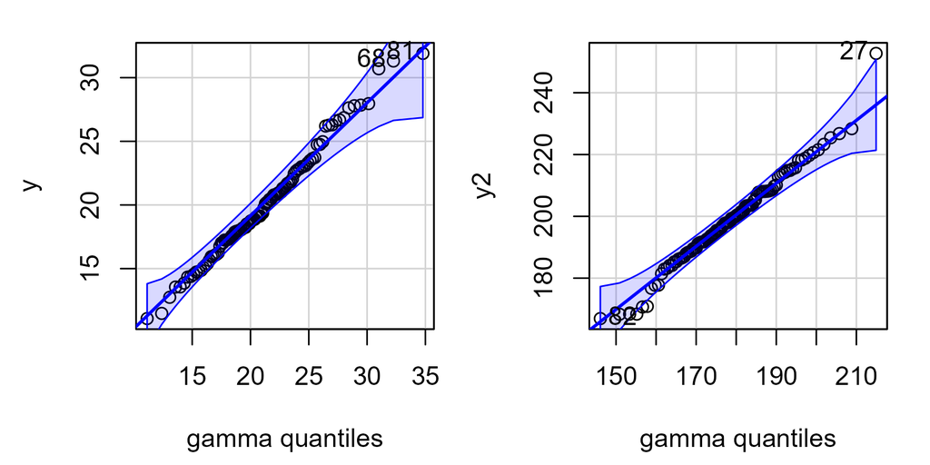

```r
par(mar = c(4, 4, 1, 1))
r <- residuals(m)
r2 <- residuals(m2)

z <- y / fitted(m)
z2 <- y2 / fitted(m2)

wrap_elements(
  full = ~ car::qqPlot(y, distribution = "gamma", shape = get_shape(m))
) +
  wrap_elements(
    full = ~ car::qqPlot(y2, distribution = "gamma", shape = get_shape(m2))
  )
```

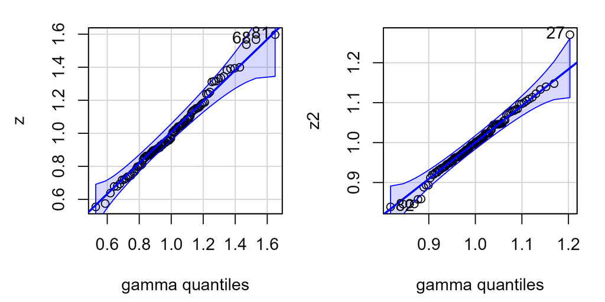

```r
wrap_elements(
  full = ~ car::qqPlot(
    z,
    distribution = "gamma",
    shape = get_shape(m),
    scale = 1 / get_shape(m))
) +
  wrap_elements(
    full = ~ car::qqPlot(
      z2,
      distribution = "gamma",
      shape = get_shape(m2),
      scale = 1 / get_shape(m2))
  )
```

### Jaccard similarity (2019-03-14)

[Jaccard similarity](https://en.wikipedia.org/wiki/Jaccard_index) is the size of intersection of A and B divided by size of union of A and B.

Suppose a listener types of a few sentences twice. These are probes for intra-listener transcription reliability. Suppose that one of these sentences is 6 words long. If a listener typed 8 unique words for the two sentences, and 4 of them appear in both sentences, then they have Jaccard similarity of 4 / 8 = 0.5. Then we take the weighted mean of the Jaccard scores. We use the sentence length as the weight, so this sentence would have a weight of 6.

Asked twitter if they knew any IRR tutorials

- https://www.ncbi.nlm.nih.gov/pmc/articles/PMC4913118/
- https://www.ncbi.nlm.nih.gov/pmc/articles/PMC3402032/

### Phylogenetic regression (2019-02-26)

Listened to bits of phylogenetic regression lecture.

- You can model a simple linear regression as a multivariate regression.
- Make the covariance matrix the identity matrix and multiple it by the error term sigma.
- In this formulation, you can swap out the identity correlation matrix with something estimated using a correlation/distance matrix. If the distances were age, you can have units with similar ages have correlated errors. Now you have a gaussian process regression.

### multicomp (2019-02-25)

- We are using the multcomp package and `glht()` to test hypotheses from fitted models. Never used this package before. Something to learn.
- `glht()` will compute a group difference (like asymptote of SMI-LCT vs SMI-LCI) from a fitted model and give you a standard error, *z* statistic and *p* value for that difference.
- I can get very similar results by sampling the multivariate normal distribution of the model coefficients/variance-covariance matrix and computing the group differences from the samples, using the standard deviation of the samples to get the standard error.

### Rolling list of bookmarks (2019-10-01)

dtool: Manage scientific data https://dtool.readthedocs.io/en/latest/

A very first introduction to Hamiltonian Monte Carlo https://blogs.rstudio.com/tensorflow/posts/2019-10-03-intro-to-hmc/

Some things you maybe didn’t know about linear regression https://ryxcommar.com/2019/09/06/some-things-you-maybe-didnt-know-about-linear-regression/

dbx database tools for R https://github.com/ankane/dbx

Dash for R https://medium.com/@plotlygraphs/announcing-dash-for-r-82dce99bae13

How to interpret F-statistic https://stats.stackexchange.com/questions/12398/how-to-interpret-f-and-p-value-in-anova

The origin of statistically significant https://www.johndcook.com/blog/2008/11/17/origin-of-statistically-significant/

tidymv: Tidy Model Visualisation for Generalised Additive Models https://cran.r-project.org/web/packages/tidymv/index.html

Step-by-step examples of building publication-quality figures in ggplot2 https://github.com/clauswilke/practical_ggplot2

From data to viz https://www.data-to-viz.com/

Shapley model explanation https://github.com/slundberg/shap

JavaScript versus Data Science https://software-tools-in-javascript.github.io/js-vs-ds/en/

Penalized likelihood estimation https://modernstatisticalworkflow.blogspot.com/2017/11/what-is-likelihood-anyway.html

UTF-8 everywhere https://utf8everywhere.org/

Unicode programming https://begriffs.com/posts/2019-05-23-unicode-icu.html

R package to simulate colorblindness https://github.com/clauswilke/colorblindr

Data version control https://dvc.org/

Email tips https://twitter.com/LucyStats/status/1131285346455625734?s=20

colorcet library (python) https://colorcet.pyviz.org/

HCL wizard http://hclwizard.org/hclwizard/

Coloring for colorblindness. Has 8 palettes of color pairs https://davidmathlogic.com/colorblind/

5 things to consider when creating your CSS style guide by (**malimirkeccita?**) https://medium.com/p/5-things-to-consider-when-creating-your-css-style-guide-7b85fa70039d

Tesseract OCR engine for R https://cran.r-project.org/web/packages/tesseract/vignettes/intro.html

Lua filters for rmarkdown documents https://github.com/crsh/rmdfiltr

An NIH Rmd template https://github.com/tgerke/nih-rmd-template

Commit message guide https://github.com/RomuloOliveira/commit-messages-guide

Linear regression diagnostic plots in ggplot2 https://github.com/yeukyul/lindia

A graphical introduction to dynamic programming https://avikdas.com/2019/04/15/a-graphical-introduction-to-dynamic-programming.html

Why software projects take longer than you think https://erikbern.com/2019/04/15/why-software-projects-take-longer-than-you-think-a-statistical-model.html

Automatic statistical reporting https://github.com/easystats/report

Multilevel models and CSD https://pubs.asha.org/doi/pdf/10.1044/2018_JSLHR-S-18-0075

Map of cognitive science http://www.riedlanna.com/cognitivesciencemap.html

An additive Gaussian process regression model for interpretable non-parametric analysis of longitudinal data https://www.nature.com/articles/s41467-019-09785-8

Common statistical tests are linear models (or: how to teach stats) https://lindeloev.github.io/tests-as-linear/

Monte Carlo sampling does not “explore” the posterior https://statmodeling.stat.columbia.edu/2019/03/25/mcmc-does-not-explore-posterior/

How to develop the five skills that will make you a great analyst https://mode.com/blog/how-to-develop-the-five-soft-skills-that-will-make-you-a-great-analyst

Confidence intervals are a ring toss https://twitter.com/epiellie/status/1073385427317465089

Mathematics for Machine Learning https://mml-book.github.io/

20 Tips for Senior Thesis Writers http://hwpi.harvard.edu/files/complit/files/twenty_tips_for_senior_thesis_writers_revised_august_2012.pdf

Comparing common analysis strategies for repeated measures data http://eshinjolly.com/2019/02/18/rep_measures/

Cosine similarity, Pearson correlation, and OLS coefficients https://brenocon.com/blog/2012/03/cosine-similarity-pearson-correlation-and-ols-coefficients/

qqplotr is a nice package for plotting qqplots https://cran.r-project.org/web/packages/qqplotr/index.html

Multidimensional item response theory https://github.com/philchalmers/mirt

Aki’s tutorials/materials on model selection https://github.com/avehtari/modelselection_tutorial

An Introverts Guide to Conferences https://laderast.github.io/2018/05/17/a-introvert-s-survival-guide-to-conferences/

Best practice guidance for linear mixed-effects models in psychological science https://psyarxiv.com/h3duq/

Viewing matrices and probabilities as graphs https://www.math3ma.com/blog/matrices-probability-graphs

Cross-validation for hierarchical models https://avehtari.github.io/modelselection/rats_kcv.html

All of Aki’s tutorials https://avehtari.github.io/modelselection/

User-friendly p values http://thenode.biologists.com/user-friendly-p-values/research/

Iodide is a Javascript notebook https://alpha.iodide.io/

Interesting question about what do when transformation changes the “test” of a highest-density interval. https://discourse.mc-stan.org/t/exponentiation-or-transformation-of-point-estimates/7848

Some ways to rethink statistical rules https://allendowney.blogspot.com/2015/12/many-rules-of-statistics-are-wrong.html

Toward a Principled Bayesian Workflow https://betanalpha.github.io/assets/case_studies/principled_bayesian_workflow.html

Stumbled across an article on mixed models and effect sizes: https://www.journalofcognition.org/articles/10.5334/joc.10/

#### I had these quotes in the old notes

> In so complex a thing as human nature, we must consider, it is hard to find rules without exception. — George Eliot

> If any one faculty of our nature may be called more wonderful than the rest, I do think it is memory…The memory is sometimes so retentive, so serviceable, so obedient; at others, so bewildered and so weak. We are, to be sure, a miracle every way; but our powers of recollecting and of forgetting do seem peculiarly past finding out. — Jane Austen

## Colophon

Notebook built using notestar, a notebook system that uses targets to create a [bookdown](https://bookdown.org/) document. Theme is [water.css](https://watercss.kognise.dev/) as provided by the [cleanrmd package](https://github.com/gadenbuie/cleanrmd).